# 257-Project

## CMPE-257-Group-11 Project Proposal

Public Repo Link: https://github.com/akashmat/CMPE-257-Group-11

Group Member Name (Github Username)

- **Akash Mattaparthy** (akashmat)
- **Dodda Sai Venkata Phanith** (phanithdsv)
- **Himaja Narina** (himajanarinaa)
- **Shravani Naikoti** (shravaninaikoti)

### 1. Novozymes Enzyme Stability Prediction

This is an ongoing competetion on Kaggle

#### 2. Dataset

Dataset taken from the Competetion site here

#### 3. Problem Description

The competetion involves the prediction of thermostability of enzyme variants (hence using regression methods). The experimentally measured thermostability (melting temperature) data includes natural sequences, as well as engineered sequences with single or multiple mutations upon the natural sequences.

Biotechnology has a basic challenge in trying to understand and reliably predict protein stability. Enzyme engineering can be used to address issues like sustainability, carbon neutrality, and other global challenges. Enzyme stability improvements may save expenses and speed up concept iteration for scientists.

#### 4. Potential Methods

1. This regression problem can be solved with ensemble methods like Random Forest, XGBoost.
2. An attempt to solve it using transformer models like BeRT will also be used.

#### 5. Create GitHub repository with a file called README.md

Public Repo Link: https://github.com/akashmat/CMPE-257-Group-11

#### 6. Preprocessing & Initial Findings

Do some intial investigation of the data (basic statistics and plots). What do you see? Any patterns? What challenges do you forsee.

```python
import matplotlib.pyplot as plt
import numpy as np
import pandas as pd
```

```python
train_df = pd.read_csv('./train.csv')
test_df = pd.read_csv('./test.csv')
```

```python
print(f"Train dataset Shape: {train_df.shape}")
print(f"Test dataset Shape: {test_df.shape}")
```

```
Train dataset Shape: (31390, 5)
Test dataset Shape: (2413, 4)
```

```python
train_df.head()
```

|  | seq_id | protein_sequence | pH | data_source | tm |
| --- | --- | --- | --- | --- | --- |
| 0 | 0 | AAAAKAAALALLGEAPEVVDIWLPAGWRQPFRVFRLERKGDGVLVG... | 7.0 | doi.org/10.1038/s41592-020-0801-4 | 75.7 |
| 1 | 1 | AAADGEPLHNEEERAGAGQVGRSLPQESEEQRTGSRPRRRRDLGSR... | 7.0 | doi.org/10.1038/s41592-020-0801-4 | 50.5 |
| 2 | 2 | AAAFSTPRATSYRILSSAGSGSTRADAPQVRRLHTTRDLLAKDYYA... | 7.0 | doi.org/10.1038/s41592-020-0801-4 | 40.5 |
| 3 | 3 | AAASGLRTAIPAQPLRHLLQPAPRPCLRPFGLLSVRAGSARRSGLL... | 7.0 | doi.org/10.1038/s41592-020-0801-4 | 47.2 |
| 4 | 4 | AAATKSGPRRQSQGASVRTFTPFYFLVEPVDTLSVRGSSVILNCSA... | 7.0 | doi.org/10.1038/s41592-020-0801-4 | 49.5 |

The columns in the training dataset:

1. seq_id: unique identifier of each protein variants
2. protein_sequence: amino acid sequence of each protein variant. The stability of a protein is determined by this protein sequence.
3. pH: measures the acidity of an aqueous solution in which the stability of protein was measured. This is important to as the stability of the same protein varies with different pH levels.
4. data_source: source where the data was published
5. tm: target column to measure the stability of protien. The higher the tm, the more statble.

```python
train_df.info()
```

```
<class 'pandas.core.frame.DataFrame'>
RangeIndex: 31390 entries, 0 to 31389
Data columns (total 5 columns):
 #   Column            Non-Null Count  Dtype
---  ------            --------------  -----
 0   seq_id            31390 non-null  int64
 1   protein_sequence  31390 non-null  object
 2   pH                31104 non-null  float64
 3   data_source       28043 non-null  object
 4   tm                31390 non-null  float64
dtypes: float64(2), int64(1), object(2)
memory usage: 1.2+ MB
```

```python
import pandas_profiling
```

```python
pandas_profiling.ProfileReport(train_df)
```

[interactive chart not shown]

#### What are some of the preprocessing techniques did you use?

```python
train_df = train_df[["seq_id", "protein_sequence", "pH", "tm"]]
train_df.head()
```

|  | seq_id | protein_sequence | pH | tm |
| --- | --- | --- | --- | --- |
| 0 | 0 | AAAAKAAALALLGEAPEVVDIWLPAGWRQPFRVFRLERKGDGVLVG... | 7.0 | 75.7 |
| 1 | 1 | AAADGEPLHNEEERAGAGQVGRSLPQESEEQRTGSRPRRRRDLGSR... | 7.0 | 50.5 |
| 2 | 2 | AAAFSTPRATSYRILSSAGSGSTRADAPQVRRLHTTRDLLAKDYYA... | 7.0 | 40.5 |
| 3 | 3 | AAASGLRTAIPAQPLRHLLQPAPRPCLRPFGLLSVRAGSARRSGLL... | 7.0 | 47.2 |
| 4 | 4 | AAATKSGPRRQSQGASVRTFTPFYFLVEPVDTLSVRGSSVILNCSA... | 7.0 | 49.5 |

```
array([[<AxesSubplot:title={'center':'pH'}>]], dtype=object)
```

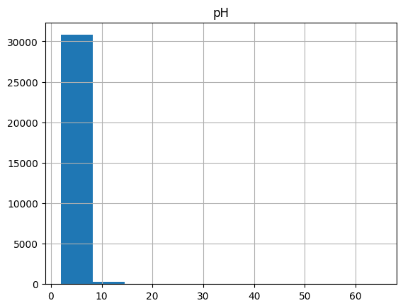

```python
train_df.hist("pH")
```

```
array([[<AxesSubplot:title={'center':'tm'}>]], dtype=object)
```

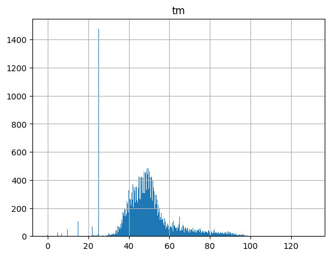

```python
train_df.hist("tm", bins=500)
```

### Challenges:

1. The high uniformity of protein_sequences can be a problem.
2. The skewed data set in terms of pH and tm can also lead to a model which is un-representative of the general data. Other datasets can be added to compensate for this.